Review Article

The non-reconstructive treatment of complete ACL tear with

biological enhancement in clinical and preclinical studies: A

systematic review

Yue Li <sup>a</sup>, Sai Cheun Fu <sup>b</sup><sup>,</sup><sup>c</sup>, Yau Chuk Cheuk <sup>b</sup><sup>,</sup><sup>c</sup>, Guanyang Song <sup>a</sup>, Hua Feng <sup>a</sup>,

Shu-Hang Yung <sup>b</sup><sup>,</sup><sup>c</sup><sup>,</sup>*

a Sports Medicine Service, Beijing Jishuitan Hospital, China

b Department of Orthopaedics and Traumatology, Faculty of Medicine, The Chinese University of Hong Kong, China

c Lui Che Woo Institute of Innovative Medicine, The Chinese University of Hong Kong, Hong Kong, China

a r t i c l e

i n f o

Article history:

Received 18 December 2017

Received in revised form

28 March 2018

Accepted 9 April 2018

Available online 18 May 2018

a b s t r a c t

Introduction: There is still controversy regarding the bio-enhanced non-reconstructive ACL treatment.

studies were extracted.

Results: Eighteen articles were included for analysis. In clinical studies, although subjective scores were

signiﬁcantly improved, the rate of re-operation rate was high. In preclinical studies, bio-enhancing

techniques demonstrated promotion of the healing of ACL.

Conclusions: The efﬁcacy of biological enhancement cannot be validated in clinical studies. Preclinical

studies showed improved biomechanical and healing potential.

© 2018 Asia Paciﬁc Knee, Arthroscopy and Sports Medicine Society. Published by Elsevier (Singapore) Pte

Ltd. This is an open access article under the CC BY-NC-ND license (http://creativecommons.org/licenses/

by-nc-nd/4.0/).

Contents

Introduction . . . . . . . . . . . . . . . . . . . . . . . . . . . . . . . . . . . . . . . . . . . . . . . . . . . . . . . . . . . . . . . . . . . . . . . . . . . . . . . . . . . . . . . . . . . . . . . . . . . . . . . . . . . . . . . . . . . . . . . 10

Materials and methods . . . . . . . . . . . . . . . . . . . . . . . . . . . . . . . . . . . . . . . . . . . . . . . . . . . . . . . . . . . . . . . . . . . . . . . . . . . . . . . . . . . . . . . . . . . . . . . . . . . . . . . . . . . . . 11

Results . . . . . . . . . . . . . . . . . . . . . . . . . . . . . . . . . . . . . . . . . . . . . . . . . . . . . . . . . . . . . . . . . . . . . . . . . . . . . . . . . . . . . . . . . . . . . . . . . . . . . . . . . . . . . . . . . . . . . . . . . . . . 11

Methodological quality assessment . . . . . . . . . . . . . . . . . . . . . . . . . . . . . . . . . . . . . . . . . . . . . . . . . . . .. . . . . . . . . . . . . . . . . . . . . . . . . . . . . . . . . . . . . . . . . . . . . 11

Clinical studies . . . . . . . . . . . . . . . . . . . . . . . . . . . . . . . . . . . . . . . . . . . . . . . . . . . . . . . . . . . . . . . . . . . . . . . . . . . . . . . . . . . . . . . . . . . . . . . . . . . . . . . . . . . . . . . . . . 11

Animal studies . . . . . . . . . . . . . . . . . . . . . . . . . . . . . . . . . . . . . . . . . . . . . . . . . . . . . . . . . . . . . . . . . . . . . . . . . . . . . . . . . . . . . . . . . . . . . . . . . . . . . . . . . . . . . . . . . . 12

Collagen-platelet composite . . . . . . . . . . . . . . . . . . . . . . . . . . . . . . . . . . . . . . . . . . . . . . . . . . . . . . . . . . . . . . . . . . . . . . . . . . . . . . . . . . . . . . . . . . . . . . . . . . . . 12

Suture repair and platelet-rich plasma . . . . . . . . . . . . . . . . . . . . . . . . . . . . . . . . . . . . . . . . . . . . . . . . . . . . . . . . . . . . . . . . . . . . . . . . . . . . . . . . . . . . . . . . . . . 14

Suture repair and small intestinal submucosa . . . . . . . . . . . . . . . . . . . . . . . . . . . . . . . . . . . . . . . . . . . . . . . . . . . . . . . . . . . . . . . . . . . . . . . . . . . . . . . . . . . . 14

Extracellular matrix sheet and gel . . . . . . . . . . . . . . . . . . . . . . . . . . . . . . . . . . . . . . . . . . . . . . . . . . . . . . . . . . . . . . . . . . . . . . . . . . . . . . . . . . . . . . . . . . . . . . . 14

Discussion . . . . . . . . . . . . . . . . . . . . . . . . . . . . . . . . . . . . . . . . . . . . . . . . . . . . . . . . . . . . . . . . . . . . . . . . . . . . . . . . . . . . . . . . . . . . . . . . . . . . . . . . . . . . . . . . . . . . . . . . 14

Conclusion . . . . . . . . . . . . . . . . . . . . . . . . . . . . . . . . . . . . . . . . . . . . . . . . . . . . . . . . . . . . . . . . . . . . . . . . . . . . . . . . . . . . . . . . . . . . . . . . . . . . . . . . . . . . . . . . . . . . . . . . 15

Conflicts of interest . . . . . . . . . . . . . . . . . . . . . . . . . . . . . . . . . . . . . . . . . . . . . . . . . . . . . . . . . . . . . . . . . . . . . . . . . . . . . . . . . . . . . . . . . . . . . . . . . . . . . . . . . . . . . . . . . 15

References . . . . . . . . . . . . . . . . . . . . . . . . . . . . . . . . . . . . . . . . . . . . . . . . . . . . . . . . . . . . . . . . . . . . . . . . . . . . . . . . . . . . . . . . . . . . . . . . . . . . . . . . . . . . . . . . . . . . . . . . . 15

Introduction

Currently, anterior cruciate ligament (ACL) reconstruction has

been considered as the primary treatment of active young adult

patients with ACL complete tear. However, there is still controversy

Prince of Wales Hospital, Shatin, NT, Hong Kong, China.

E-mail address: patrickyung@cuhk.edu.hk (S.-H. Yung).

[figure not shown]

Asia-Paciﬁc Journal of Sports Medicine, Arthroscopy,

Rehabilitation and Technology

journal homepage: www.ap-smart.com

[figure not shown]

https://doi.org/10.1016/j.asmart.2018.04.002

license (http://creativecommons.org/licenses/by-nc-nd/4.0/).

regarding

the

best

treatment

algorithm

of

ACL

tear

in

adolescent,<sup>1</sup><sup>e</sup><sup>4</sup>the middle-aged to elderly,<sup>5</sup><sup>,</sup><sup>6</sup>skeletally immature

and low-demanding adult patients. In addition, tendon-bone

healing,<sup>7</sup>donor site morbidity,<sup>8</sup>destruction of proprioception and

vascularity, and non-anatomic placement were all potential prob-

lems for reconstructive treatment. Non-reconstructive approach

primarily avoids the use of graft and extra trauma caused by drilling

bone tunnels, and probably preserves more proprioception with

less destruction of ACL footprint.

Theoretically, torn ACL has healing potential.<sup>9</sup>However, the

outcome of non-reconstructive ACL treatment was not promising.

In a long-term follow-up study, Sanders et al.<sup>10</sup>demonstrated 18-

fold likelihood of secondary meniscal tears, 14-fold of arthritis,

and

5-fold

of

need

of

total

knee

arthroplasty

with

non-

reconstructive

treatment

comparing

with

ACLR.

Similarly,

discouraging outcome of ACL single repair was also reported by a

recent systematic review.<sup>3</sup>From the above discouraging results, it

seems that the self-healing capacity of ACL is very low, biological

enhancement of healing may be necessary to keep the advantages

of non-reconstructive surgery and ensure sufﬁcient healing re-

sponses and good clinical outcomes.

The biological enhancement technique in ACL reconstruction

has been well discussed in a systematic review by Fu et al.<sup>11</sup>They

suggested that biological modulation is able to promote healing at

the tunnel-graft interface. But the healing of the intra-articular

midsubstance

of

the

graft

was

another

consideration.

We

included clinical and extended to preclinical studies that may

provide more advanced insight for the further ACL tear treatment.

In the literature, “Healing Response Technique” (HRT) and “Dy-

namic Intraligamentous Stabilization” (DIS) are two mainly used

techniques in clinical studies, while a variety of innovative tech-

niques were also applied in animal studies. HRT was described as

perforating cortical bone at the femoral origin and the rupture

stump, while DIS is employing internal stabilizer to keep the un-

stable knee in a posterior translation, combined with micro-

fracturing and platelet-rich ﬁbrin induction at the rupture site to

promote self-healing.

The purpose of the systematic review was to describe the clin-

ical outcome and results of animal studies on non-reconstructive

treatment of complete anterior cruciate ligament (ACL) tear with

biological enhancement.

Materials and methods

We searched the Medline, Scopus and Ovid database in January

2018 to identify all clinical and preclinical studies about the treat-

ment of complete ACL tear with non-reconstructive biological

enhancement techniques based on the following criteria: (ACL OR

anterior cruciate ligament) AND (repair OR healing) NOT (recon-

struct*). The references of all included studies and related reviews

were also checked. The inclusion criteria were (1) English original

articles published from January 1, 2000 to January 20, 2018; (2)

clinical or animal in vivo studies; (3) complete ACL tear; (4) and

healing of ACL was enhanced by the use of bone marrow stimula-

tion, mesenchymal stem cells, growth factors, biomaterials, drugs

or biophysical intervention (biological enhancement). Articles were

excluded if they (1) were reviews, meta-analyses, case reports, or

technical notes; (2) had application of any type of graft; (3)

included concomitant posterior cruciate ligament and posterolat-

eral complex lesions and patellofemoral disorders. It should be

noted that since the management for ACL partial tear is different

from complete tear and the relevant articles of partial tear was too

few to synthesize, articles about partial tear were also excluded. All

included studies retrieved from the search engines were initially

checked manually by 2 independent co-authors by reviewing titles,

abstracts and full-text articles for ﬁnal application of the inclusion

and exclusion criteria. Any discrepancies were discussed and

overcome by consensus.

The full texts of the ﬁltered included articles were then obtained

for data extraction. Data from clinical studies were mainly publi-

cation years, ﬁrst author, type of biological enhancement and

combined surgery, sample size, patients' demographic data, key

objective and subjective outcome measures, and other major

ﬁndings. Data from animal studies were mainly publication years,

ﬁrst author, type of biological enhancement and combined surgery,

animal model, sample size, grouping methods, time of sacriﬁce,

histological or radiological results, laxity data, and biomechanical

data.

Assessment of quality of clinical studies and animal studies was

then performed by two experienced clinicians and two senior re-

searchers, respectively. Clinical studies were assessed with meth-

odological index for non-randomized studies (MINORS).<sup>12</sup>Since

there were four additional criteria for comparative study, the ideal

score was 16 for non-comparative studies and 24 for comparative

studies. Animal studies were assessed according to the criteria

adapted from the checklist of Hooijmans et al.<sup>13</sup>The average score

of the two reviewers were recorded as the ﬁnal score.

Results

The initial research resulted in 1023 articles. After the ﬁltered

research, 508 articles were excluded for publication date, type and

language. The review on titles was conducted on 515 articles. After

the exclusion of 380 irrelevant articles, 135 articles were available

for further screening. Twenty-two eligible articles were retrieved. It

should be noted that the article written by Eggli et al., in 2015<sup>14</sup>

included the same series as they published in 2016<sup>15</sup>, so the

earlier article was not included for analysis. So 18 articles were

ﬁnally included for analysis. Among them, seven articles were

clinical studies and 11 articles were animal studies. Of the 7 clinical

(Fig. 1). There were three techniques discussed in all 7 articles,

HRT in 3 studies, DIS repair in 3 studies and bridge-enhanced ACL

repair. One of the level Ⅲ studies compared the outcome of DIS

repair with and without additional collagen application.<sup>19</sup>The

other one compared the HRT and conservative treatment.<sup>17</sup>Of the

11 animal studies, six compared bio-enhanced ACL repair and su-

ture repair only,<sup>1</sup><sup>,</sup>21e26 one compared bio-enhanced repair with

ACL reconstruction,<sup>27</sup>and compared the outcome of bio-enhanced

ACL repair with different ﬁxation methods,<sup>28</sup>platelet-rich plasma

(PRP) injection temperature,<sup>29</sup>concentration of PRP<sup>30</sup>and time of

delay.<sup>31</sup>

Methodological quality assessment

control and 1 cohort studies. The quality scores were listed in the

last column of Table 1. According to MINORS scoring system,

comparative studies was evaluated by 4 more items than case-

as low-quality studies. Good interobserver reliability was obtained

between assessors (intraclass correlation coefﬁcient, 0.882; animal

studies, intraclass correlation coefﬁcient, 0.807), and consensus on

scoring was reached by discussion.

Clinical studies

In total, 193 knees (129 male, 64 female) were evaluated at a

minimum follow-up of 2 years. Of all 193 knees, 91 knees (47.2%)

were treated with HRT which is fundamentally microfracture at the

femoral insertion site without suturing ACL,102 knees (52.8%) were

treated with DIS repair with biological enhancement technique,

and 10 knees were treated with bridge-enhance ACL repair pro-

cedure (BEAR) (Table 1).

All studies reported the Lysholm and Tegner score at the ﬁnal

follow-up. For HRT studies, the median or mean Lysholm scores

ranged from 90 to 96 scores. The median or mean Tegner scores

ranged from 5 to 8.5 scores, and failure rate from 8.9% to 36%. For

DIS studies, the median or mean Lysholm scores ranged from 97 to

100 scores. The median or mean Tegner scores ranged from 5.1 to 6

scores, and failure rate from 0% to 20%. The BEAR scaffold in Murray

et al.'s clinical study<sup>20</sup>is the only device that ﬁlls the gap between

the torn ligament ends to have current Investigational Device

Exemption approval from the Food and Drug Administration. At 3-

month follow-up, no joint infections or signs of signiﬁcant

inﬂammation were observed. There were no differences between

groups in effusion or pain, and no failures by Lachman examination

criteria or MRI evaluation.

Animal studies

There were 11 eligible animal studies included for quantitative

synthesis (Table 2). Among them, there were 8 studies on pigs, 1 on

minipigs and 2 on goats. The biological enhancement was mainly

focused on 4 techniques: bio-enhanced ACL repair with collagen-

platelet composite (CPC) combined with bone marrow stimula-

tion or other biomaterials,<sup>27</sup>suture repair enhanced by PRP, locking

suture technique with small intestinal submucosa (SIS) and suture

repair wrapped by extracellular matrix (ECM) bioscaffolds and

injected with ECM hydrogel.<sup>25</sup>

Collagen-platelet composite

In the 7 studies<sup>21</sup><sup>,</sup><sup>22</sup><sup>,</sup>27e31 focusing on the application of CPC.

Among them, three of four studies<sup>21</sup><sup>,</sup><sup>22</sup><sup>,</sup><sup>27</sup><sup>,</sup><sup>28</sup>that made direct com-

parison between bio-enhanced repair and repair only favored the

bio-enhanced ACL repair. Vavken et al.<sup>27</sup>proved that bio-enhanced

ACL repair produced similar anterior-posterior (AP) laxity at 30<sup>�</sup>,

60ºand 90<sup>�</sup>, maximum load, maximum displacement and linear

stiffness with ACLR in a skeletally immature, large animal model.

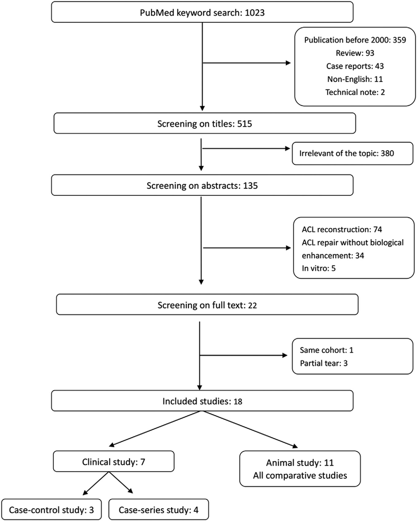

Fig. 1. PRISMA (Preferred Reporting Items for Systematic Reviews and Meta-Analyses) ﬂowchart.

Joshi et al.<sup>22</sup>discovered the technique produced the CPC ligaments

a 76% greater yield at load, a 320% increase in linear stiffness, and a

47% decrease in the displacement at yield comparing with suture

repair only after 3 months of healing. Histologically, although the

CPC group had a signiﬁcantly higher proportion of fusiform cells at

the 3-month time point than suture only group, there were still

signiﬁcant difference in cellularity, cell shape, vascularity, and

collagen organization from intact ligament. Murray et al.<sup>28</sup>modi-

ﬁed the ﬁxation to a bone-to-bone fashion and proved its

enhancement of yield load and linear stiffness comparing with

bone-to-ligament ﬁxation. However, the AP laxity of both tech-

niques was still signiﬁcantly greater than the intact knee.

On the contrary, Kiapour<sup>21</sup>discovered that when treated with

absorbable suture, females had a lower ACL linear stiffness, yield

load, maximum load and AP stability at 30<sup>�</sup>than suture repair only.

The condition of CPC application was also discussed. Magarian<sup>32</sup>

reported that after a delay of 2 or 6 weeks between transection and

repair, the yield load of at postoperative 15 weeks was decreased by

40% and 60%, maximum load decreased 55% and 60%, linear stiff-

ness decreased 50% and 50%, and AP laxity was 40% and 10% higher,

Table 1

Summary of clinical studies.

Study

Study

design

Patients

included

M:F

Average

age, yr

Mean F/

U, mo

Bio-enhancement

techniques

Surgical

procedure on ACL

Rate of

reoperation

Assessment of outcome

MINORS

Steadman et al.<sup>2</sup>Case

series

13

9:4

13

69

Bone marrow

stimulation

ACL perforation

23.1%

Instrumented SSD: 5 (3e10)mm

Lysholm: 96, Tegner: 8.5

11

Steadman

et al.<sup>16</sup>

Case

series

48

13:35 51

91.2

Bone marrow

stimulation

ACL perforation

8.9%

More than 90% lower than

Lachman Grade 3

Lysholm: 90, Tegner: 5

10

Wasmaier

et al.<sup>17</sup>

Case

series

28

20:10 30.5

51.0

Bone marrow

stimulation

ACL perforation

36%

Signiﬁcant higher anterior knee

laxity

Lysholm: 91.2, Tegner: 5.7

16

Evangelopoulos

et al.<sup>19</sup>

Case

control

Study: 23

Control: 33

39:17 30

24

Collagen membrane DIS repair

0%

Study group vs control group

Instrumented SSD: 1.0 mm vs

1.0 mm

Lysholm: 100 vs 95

Tegner: 6 vs 5

19

Henle et al.<sup>18</sup><sup>,</sup><sup>a</sup>

Case

series

69

42:27 32.4

�24

Microfracturing

Sutures and DIS

2.9%

Instrumented SSD: 2.3 mm

Lysholm: 97, Tegner: 5.1, IKDC:

94.8

10

Eggli et al.<sup>15</sup>

Case

series

10

8:2

23.3

60.3

Microfracturing

Sutures and DIS

20%

Instrumented SSD: 2 mm

Lysholm: 100, Tegner: 5.5, IKDC:

98.9

10

Murray et al.<sup>20</sup>

Cohort

Study: 10

Control: 10

6:14

24

3

BEAR scaffold

Suture

0%

Study group vs control group

Lachman test: 8 grade A, 2 grade B

vs 10 grade A

IKDC: 54.3 vs 60.7

20

M, male; F, female; mo, months; yr, year; F/U, follow-up; d, day; mo, month NP, not provided; HRT, healing response technique; DIS, dynamic intraligamentary stabilization.

a There were 278 patients included in this study but only 69 patients were followed for a minimum of 2 years. The M:F, age at surgery, time from injury to surgery were

obtained from the overall data.

Table 2

Summary of animal studies.

Study

Animals Study design

F/U

Outcome

Vavken

et al.<sup>14</sup>

24 pigs

CPC vs ACLR vs control

15 wk CPC and ACLR produced superior biomechanical outcomes to control group.

Kiapour

et al.<sup>18</sup>

17 pigs

CPC vs control

15 wk CPC showed worse mechanical outcome than control group

Murray

et al.<sup>23</sup>

12 pigs

CPC with ligament ﬁxation

vs tibial ﬁxation

15 wk Tibial ﬁxation signiﬁcantly improved mechanical outcomes.

Joshi et al.<sup>19</sup>

27 pigs

CPC vs control

4 wk

6 wk

3 mo

CPC showed in improvements in mechanical and histological assessments at 3 months.

Murray

et al.<sup>20</sup>

5 pigs

Hydrogel-PRP vs control

4 wk

Hydrogel-PRP showed improvements in mechanical assessments.

Magarian

et al.<sup>26</sup>

16 pigs

CPC immediate repair vs

delay of 2wks vs 6wks

15 wk Delay of 2wks and 6wks both showed inferior mechanical outcomes and laxity test results.

Nguyen

et al.<sup>21</sup>

10 goats Locking suture technique with and

without SIS vs intact control

12 wk The cross-sectional area of two suture groups was 35% and 50% of the intact control, respectively.

Suture-SIS group showed mechanical improvement than the Suture group at 30<sup>�</sup>.

Palmer

et al.<sup>24</sup>

4 pigs

CPC repair at 28.9e32.4 <sup>�</sup>C

14 wk The mechanical property and histological outcome were inversely correlated with injection

temperature.

Fisher et al.<sup>22</sup>16 goats ECM sheet and hydrogel vs control

12 wk The cross-sectional area and mechanical outcomes of ECM study group were signiﬁcant better than

control.

Murray

et al.<sup>1</sup>

6 pigs

PRP vs control

14 wk No signiﬁcant mechanical improvement in PRP group

Mastrangelo

et al.<sup>25</sup>

8

minipigs

Two groups:

CPC with PRP 5x vs 3x baseline of

platelets

ACL, anterior cruciate ligament; CPC, collagen platelet composite; F/U, follow up; wk, week; mo, month; PRP, platelet-rich plasma; AP, anterior-posterior; SIS, small intestinal

submucosa; ECM, extra-cellular matrix.

respectively. Mastrangelo<sup>30</sup>reduced the concentration of PRP

within the CPC from 5 times of systemic baseline to 3 times. There

was no signiﬁcant deterioration in biomechanical properties or AP

laxity at 30ºand 90<sup>�</sup>, but signiﬁcant greater laxity at 60<sup>�</sup>, and worse

collagen formation and maturity index). Palmer<sup>29</sup>conducted a

research on the effect of application temperature of CPC on the

ligament. In the in vitro study, injection temperatures of over 30 <sup>�</sup>C

resulted in gels with 50% lower stiffness than those below 30 <sup>�</sup>C. In

the in vivo study, CPCs injected at a higher temperature resulted in

50% of the repair strength when the temperature increased from

29 <sup>�</sup>C to 32.5 <sup>�</sup>C.

Suture repair and platelet-rich plasma

Two studies reported the results after PRP application. Murray

et al. <sup>23</sup>injected hydrogel-PRP to the repair site enhance the suture

repair. In the comparison with suture only, the bio-enhanced repair

acquired 164%, 123% and 110% increase for load at yield, maximum

load and tangent modulus, respectively, although the above pa-

rameters were still inferior to intact knee. However, in another

study by Murray et al.,<sup>1</sup>they concluded that PRP alone was not

sufﬁcient to enhance ACL suture repair in terms of AP laxity and

biomechanical properties.

Suture repair and small intestinal submucosa

In the study by Nguyen et al.,<sup>24</sup>ACLs were sutured with

customized-Becker suture technique. Goats were divided into two

groups, suture only group and suture þ SIS group in which six small

pieces of SIS (2 mm*2 mm*200 mm) were placed within the mid-

substance of the injury site. After 12 weeks of healing, the AP

laxity at 30<sup>�</sup>, 60ºand 90<sup>�</sup>was signiﬁcantly greater in both groups

than control. Gross morphology showed that the healing ACL was

continuous with collagenous tissue in both groups. The cross-

sectional area of the Suture and the Suture þ SIS group was 35%

and50% of the intact control, respectively.

Extracellular matrix sheet and gel

In the research by Fisher et al.,<sup>25</sup>sixteen skeletally mature ACL-

transected goats were divided into two groups, the ECM-treated

group in which an ECM sheet was wrapped around the injury site

and with an ECM hydrogel injected into the transected site and the

suture repair group in which the ACL was repaired by suture only. It

demonstrated that the AP laxity of the ECM treated group was

signiﬁcantly greater than the sham control. Histologically, all ECM-

treated ACLs healed with continuous neo-tissue formation and no

noticeable concavities while only a small amount of neo-tissue

formation in the suture repair group. The cross-sectional area of

the ECM-treated group was similar to sham operated controls and

was 4.5 times those of suture repair group. Biomechanically, stiff-

ness and ultimate load for the ECM-treated reached 48% and 20% of

the sham control. They concluded that the application of an ECM

bio-scaffold and hydrogel was found to accelerate the healing of a

transected ACL following suture repair but failed to fully restore the

function of normal ACL.

Discussion

The most important ﬁnding of the systematic review was (1)

improved biomechanical and healing potential in bio-enhanced

ACL non-reconstructive treatment, (2) the satisfactory subjective

outcome but an unacceptable high rate of re-instability and reop-

eration, especially for some studies with HRT, although the validity

of the ﬁndings were limited by low level of evidence.

In a systematic review of primary ACL repair, 20%e64% of patients

underwent revision for re-instability.<sup>3</sup><sup>,</sup><sup>33</sup>In a 32-year follow-up

study by Taylor et al.,<sup>34</sup>28% of patients ultimately underwent an

additional procedure for persistent symptomatic instability. Simi-

larly, in the study by Strand et al.,<sup>35</sup>at a 15e23-year follow-up, the

rate of instability was as high as 43%. Since the discouraging clinical

outcome of ACL single repair,<sup>3</sup><sup>,</sup><sup>35</sup>ACLR has become a popular treat-

ment of ACL rupture. However, comparing with non-reconstructive

treatment, ACLR was not advantageous in skeletally immature,

adolescent,<sup>36</sup>elder and non-active patients. In addition, the bone-

tendon healing,<sup>7</sup>donor site morbidity,<sup>8</sup>non-anatomic placement

were also potential problems. If ACL repair can be successfully ach-

ieved, several advantages can be further provided, including the

preservation of natural anatomy (femoral and tibial insertion sites

and multi-bundle nature), proprioception, and vascularity.<sup>37</sup>

Unfortunately,

unlike

extra-articular

ligament

like

medial

collateral ligament (MCL) which can successfully heal within blood

clot formation, the healing potential of ACL was compromised by

the abundance of plasmin in synovial ﬂuid which is an efﬁcient

cleaver of ﬁbrin clot.<sup>38</sup>In addition to the hostile environment, ACL

healing can also be compromised by biological factors such as cell

deﬁciencies and alterations in cellular metabolism.<sup>14</sup>Given the

poor healing capability of nature ACL, several biological enhance-

ment techniques for ACL healing have been proposed. So the goal of

this systematic review was to synthesize the results of preclinical

and clinical studies respectively.

All included animal studies were comparative studies. Of the 11

animal studies, six compared bio-enhance ACL repair and suture

repair only<sup>1</sup><sup>,</sup>21e25<sup>,</sup><sup>28</sup>and one compared bio-enhanced repair with

ACL reconstruction. The results were still controversial. Two studies

reported discouraging results. Murray et al.<sup>1</sup>found that PRP only

was not sufﬁcient to enhance ACL healing. Kiapour et al.<sup>21</sup>

demonstrated inferior linear stiffness, ACL yield, maximum load,

and AP stability in female subjects with bio-enhanced repair than

non-absorbable suture repair. However, the other four studies

support that bio-enhancement technique did improve at least some

of the biomechanical or laxity properties. In a comparison with ACL

reconstruction, Vavken et al.<sup>27</sup>showed that bio-enhanced ACL

repair produced similar biomechanical results with ACL recon-

struction in a skeletally immature porcine model. If we categorized

the studies into different approaches of enhancement, the CPC was

most discussed and favored by most studies.

In terms of clinical studies, the rates of re-instability were 8.9%,

In terms of the re-operation rates, for HRT they were 8.9%, 23.1%

less active population (mean age: 51, ﬁnal Tegner score: 5) than

Wasmaier et al.'s cases (mean age: 31, ﬁnal Tegner score: 5.7)

whose re-operation rate was 36%. It seems that the DIS technique

acquired relatively lower rate of re-instability and re-operation.

According to literature, there are two main factors that inﬂuence

the wound healing, mechanical and biological environment.<sup>39</sup>In

terms of the mechanical environment, the major difference be-

tween these two techniques was the structural continuity provided

by intraligamentous stabilizer. DIS acted as an internal brace that

provided torn ACL a stable mechanical environment for healing.

Although patients were locked in full extension with weight-

bearing for a total of 6 weeks and the ACL stump was held by

marrow clots, the anterior tibial translation and micro-movement

in synovial ﬂuid might be inevitable.

On the other hand, in terms of biological environment, in

addition to microfracture, Eggli et al.<sup>15</sup>also introduced leukocyte-

and platelet-rich ﬁbrin, and Evangelopoulos et al.<sup>19</sup>applied

collagen scaffold with DIS technique which could also be a reason of

better outcome. The only study comparing ACL repair and ACLR was

an early feasibility cohort study which was only followed for 3

months.<sup>40</sup>The percent recovery of hamstring strength was greater

at 3 months for the bio-enhanced group. No signiﬁcant difference

was detected in terms of adverse events, objective and subjective

assessments and MRI (magnetic resonance imaging) ﬁndings.

The only study that had been translated from preclinical to

clinical application was performed by Murray et al.<sup>20</sup>The effec-

tiveness of BEAR scaffold which was the only device that ﬁlls the

gap between the torn ligament ends to have current Investigational

Device Exemption approval from the Food and Drug Administration

has been proved by some of the preclinical studies that included in

our review.<sup>22</sup><sup>,</sup><sup>26</sup><sup>,</sup><sup>41</sup>In Murray et al.'s early pilot clinical study,<sup>20</sup>no

signiﬁcant adverse event or no difference in terms of effusion or

pain or objective evaluations were observed in the 10 patients

treated with BEAR procedure, although the follow-up was only 3

month. Providing ACL a stable mechanical environment for healing

and an enhanced biological environment, and veriﬁed by preclin-

ical studies, the long-term validity of BEAR procedure is promising.

This study is mainly focused on ACL complete tear, however, a

glimpse at the results of biological enhancement of partial tear

healing may be inspiring. Although the evidence was limited, the

outcome of biological enhancement in the treatment of ACL partial

tear seemed promising. Gobbi et al.<sup>42</sup>treated incomplete proximal

ACL tears with single repair and bone marrow stimulation. At a

mean of 25.3 months (range, 17e38 months) follow-up, the SSD

reduced from 3.5 mm to 1.3 mm. Tegner, Marx and Noyes score

signiﬁcantly improved and restored to a similar level as pre-injury.

Seijas et al.<sup>43</sup>applied PRGF-Endoret in the remaining intact bundle

for football players. Fourteen of 19 patients returned to their pre-

injury sports level 9 or 10 at 2-year follow-up. Murray et al.<sup>23</sup>

demonstrated signiﬁcant effects on the composition of tissue

ﬁlling the wound, increasing the presence of some cytokines to a

similar level of that observed in the extra-articular ligament after

the application of collagen-PRP hydrogel on an ACL central-wound

model. It should be noted that although the results seems prom-

ising, partial tear of the ACL needs more extensive work and dis-

cussion in near future with more evidence.

The preservation of proprioception was considered a main

advantage of ACL repair. Henle et al.<sup>18</sup>attributed their excellent

clinical outcome to the preservation of proprioception. However,

none of the 7 included clinical studies or studies on partial tear

conducted any assessment on proprioception. Although it's not the

same grade of preservation, remnant preserving in ACLR might also

provide some information. In a study by Hong et al.,<sup>44</sup>the passive

angle reproduction test result at 15<sup>�</sup>was 3.6<sup>�</sup>± 1.8<sup>�</sup>in the remnant

preserving group and 3.9<sup>�</sup>± 2.2<sup>�</sup>in the standard ACLR group

(P ¼ 0.739). In contrast, in another study,<sup>45</sup>the ﬁnal accuracy of

joint position sense of remnant preserving group was signiﬁcantly

better than standard ACLR (0.7 ± 0.7<sup>�</sup>vs. 1.7 ± 1.2<sup>�</sup>, p < 0.05).

The timing of ACL repairing was also discussed. Magarian et al.<sup>31</sup>

compared the biomechanical properties of ACL repair at time zero,

a delay of 2 weeks and 6 weeks. It demonstrated that the yield load

decreased by 40% and 60%, maximum load by 55% and 60%, and

linear stiffness by 50% and 50% in the group of 2-week and 6-week

delay, respectively. AP laxity was 40% higher after 2-week delay and

10% higher after 6-week delay. In the present review of clinical

studies, surgeries were performed within a mean of 18 days from

initial injury. And all animal studies performed repair at time zero.

So it seemed that the ruptured ACL should be repaired in acute

phase.

There were some limitations in the present study. First, we

classiﬁed marrow stimulation as a bio-enhancement approach, but

the component of blood clot was different from traditional blood-

derived bio-enhancement approach, like PRP. PRP is a concen-

trated source of platelet and contains a large amount of native

growth factors without erythrocytes that would be expected to

undergo necrosis shortly after clot formation,<sup>46</sup>while blood clot

contains all components of full blood without concentration. Sec-

ond, there is a chance that we may miss some relevant study

because of publication bias and some gray literature. Third, only 2

enhancement technique was not homogeneous for both clinical

and animal studies, although we illustrated the results according to

different techniques. Fifth, some animal studies of the bio-

enhanced ACL repair and suture repair are from the same

research group, so the results may be biased. Last, the results of

animal studies cannot be directly interpreted to human outcomes.

Conclusion

The efﬁcacy of biological enhancement cannot be validated

because of the low level of evidence of included studies. Animal

studies showed improved biomechanical and healing potential in

bio-enhanced ACL non-reconstructive treatment.

Conﬂicts of interest

The authors have declared no ﬁnancial conﬂicts of interest with

respect to their authorship and publication of this work.

References

1. Murray MM, Palmer M, Abreu E, Spindler KP, Zurakowski D, Fleming BC.

Platelet-rich plasma alone is not sufﬁcient to enhance suture repair of the ACL

in skeletally immature animals: an in vivo study. J Orthop Res. 2009;27:

639e645.

2. Steadman JR, Cameron-Donaldson ML, Briggs KK, Rodkey WG. A minimally

invasive technique (“healing response”) to treat proximal ACL injuries in

skeletally immature athletes. J Knee Surg. 2006;19:8e13.

3. Taylor SA, Khair MM, Roberts TR, DiFelice GS. Primary repair of the anterior

cruciate ligament: a systematic review. Arthroscopy. 2015;31:2233e2247.

4. Webster KE, Feller JA. Exploring the high Reinjury rate in younger patients

undergoing anterior cruciate ligament reconstruction. Am J Sports Med.

2016;44:2827e2832.

5. Struewer J, Ziring E, Oberkircher L, Schuttler KF, Efe T. Isolated anterior cruciate

ligament reconstruction in patients aged ﬁfty years: comparison of hamstring

graft versus bone-patellar tendon-bone graft. Int Orthop. 2013;37:809e817.

6. Barber FA, Aziz-Jacobo J, Oro FB. Anterior cruciate ligament reconstruction

using

patellar

tendon

allograft:

an

age-dependent

outcome

evaluation.

Arthroscopy. 2010;26:488e493.

7. Kanazawa T, Soejima T, Noguchi K, et al. Tendon-to-bone healing using

autologous bone marrow-derived mesenchymal stem cells in ACL reconstruc-

tion without a tibial bone tunnel-A histological study. Muscles Ligaments Ten-

dons J. 2014;4:201e206.

8. Seijas R, Rius M, Ares O, Garcia-Balletbo M, Serra I, Cugat R. Healing of donor

site in bone-tendon-bone ACL reconstruction accelerated with plasma rich in

growth factors: a randomized clinical trial. Knee Surg Sports Traumatol Arthrosc.

2015;23:991e997.

9. Seitz H, Menth-Chiari WA, Lang S, Nau T. Histological evaluation of the healing

potential of the anterior cruciate ligament by means of augmented and non-

augmented repair: an in vivo animal study. Knee Surg Sports Traumatol

Arthrosc. 2008;16:1087e1093.

10. Sanders TL, Pareek A, Kremers HM, et al. Long-term follow-up of isolated ACL

tears treated without ligament reconstruction. Knee Surg Sports Traumatol

Arthrosc. 2017 Feb;25(2):493e500.

11. Fu SC, Cheuk YC, Yung SH, Rolf CG, Chan KM. Systematic review of biological

modulation of healing in anterior cruciate ligament reconstruction. Orthop J

Sports Med. 2014;2, 2325967114526687.

12. Slim K, Nini E, Forestier D, Kwiatkowski F, Panis Y, Chipponi J. Methodological

index for non-randomized studies (minors): development and validation of a

new instrument. ANZ J Surg. 2003;73:712e716.

13. Hooijmans CR, Leenaars M, Ritskes-Hoitinga M. A gold standard publication

checklist to improve the quality of animal studies, to fully integrate the Three

Rs, and to make systematic reviews more feasible. Altern Lab Anim. 2010;38:

167e182.

14. Eggli S, Kohlhof H, Zumstein M, et al. Dynamic intraligamentary stabilization:

novel technique for preserving the ruptured ACL. Knee Surg Sports Traumatol

Arthrosc. 2015;23:1215e1221.

15. Eggli S, Roder C, Perler G, Henle P. Five year results of the ﬁrst ten ACL patients

treated with dynamic intraligamentary stabilisation. BMC Muscoskel Disord.

2016;17:105.

15

16. Steadman JR, Matheny LM, Briggs KK, Rodkey WG, Carreira DS. Outcomes

following healing response in older, active patients: a primary anterior cruciate

ligament repair technique. J Knee Surg. 2012;25:255e260.

17. Wasmaier J, Kubik-Huch R, Pﬁrrmann C, Grehn H, Bieg C, Eid K. Proximal

anterior cruciate ligament tears: the healing response technique versus con-

servative treatment. J Knee Surg. 2013;26:263e271.

18. Henle P, Roder C, Perler G, Heitkemper S, Eggli S. Dynamic Intraligamentary

Stabilization (DIS) for treatment of acute anterior cruciate ligament ruptures:

case series experience of the ﬁrst three years. BMC Muscoskel Disord. 2015;16:

27.

19. Evangelopoulos DS, Kohl S, Schwienbacher S, Gantenbein B, Exadaktylos A,

Ahmad SS. Collagen application reduces complication rates of mid-substance

ACL tears treated with dynamic intraligamentary stabilization. Knee Surg

Sports Traumatol Arthrosc. 2015.

20. Murray MM, Flutie BM, Kalish LA, et al. The bridge-enhanced anterior cruciate

ligament repair (BEAR) procedure: an early feasibility cohort study. Orthop J

Sports Med. 2016;4, 2325967116672176.

21. Kiapour AM, Fleming BC, Murray MM. Biomechanical outcomes of bridge-

enhanced anterior cruciate ligament repair are inﬂuenced by sex in a pre-

clinical model. Clin Orthop Relat Res. 2015;473:2599e2608.

22. Joshi SM, Mastrangelo AN, Magarian EM, Fleming BC, Murray MM. Collagen-

platelet composite enhances biomechanical and histologic healing of the

porcine anterior cruciate ligament. Am J Sports Med. 2009;37:2401e2410.

23. Murray MM, Spindler KP, Abreu E, et al. Collagen-platelet rich plasma hydrogel

enhances primary repair of the porcine anterior cruciate ligament. J Orthop Res.

2007;25:81e91.

24. Nguyen DT, Geel J, Schulze M, et al. Healing of the goat anterior cruciate lig-

ament after a new suture repair technique and bioscaffold treatment. Tissue

Eng. 2013;19:2292e2299.

25. Fisher MB, Liang R, Jung HJ, et al. Potential of healing a transected anterior

cruciate ligament with genetically modiﬁed extracellular matrix bioscaffolds in

a goat model. Knee Surg Sports Traumatol Arthrosc. 2012;20:1357e1365.

26. Fleming BC, Magarian EM, Harrison SL, Paller DJ, Murray MM. Collagen scaffold

supplementation does not improve the functional properties of the repaired

anterior cruciate ligament. J Orthop Res. 2010;28:703e709.

27. Vavken P, Fleming BC, Mastrangelo AN, Machan JT, Murray MM. Biomechanical

outcomes after bioenhanced anterior cruciate ligament repair and anterior

cruciate ligament reconstruction are equal in a porcine model. Arthroscopy.

2012;28:672e680.

28. Murray MM, Magarian E, Zurakowski D, Fleming BC. Bone-to-bone ﬁxation

enhances functional healing of the porcine anterior cruciate ligament using a

collagen-platelet composite. Arthroscopy. 2010;26:S49eS57.

29. Palmer MP, Abreu EL, Mastrangelo A, Murray MM. Injection temperature

signiﬁcantly affects in vitro and in vivo performance of collagen-platelet

scaffolds. J Orthop Res. 2009;27:964e971.

30. Mastrangelo AN, Vavken P, Fleming BC, Harrison SL, Murray MM. Reduced

platelet concentration does not harm PRP effectiveness for ACL repair in a

porcine in vivo model. J Orthop Res. 2011;29:1002e1007.

31. Magarian

EM,

Fleming

BC,

Harrison

SL,

Mastrangelo

AN,

Badger

GJ,

Murray MM. Delay of 2 or 6 weeks adversely affects the functional outcome of

augmented primary repair of the porcine anterior cruciate ligament. Am J

Sports Med. 2010;38:2528e2534.

32. Magarian EM, Vavken P, Connolly SA, Mastrangelo AN, Murray MM. Safety of

intra-articular use of atelocollagen for enhanced tissue repair. Open Orthop J.

2012;6:231e238.

33. Drogset JO, Grontvedt T, Robak OR, Molster A, Viset AT, Engebretsen L.

A sixteen-year follow-up of three operative techniques for the treatment of

acute ruptures of the anterior cruciate ligament. J Bone Joint Surg Am. 2006;88:

944e952.

34. Taylor DC, Posner M, Curl WW, Feagin JA. Isolated tears of the anterior cruciate

ligament: over 30-year follow-up of patients treated with arthrotomy and

primary repair. Am J Sports Med. 2009;37:65e71.

35. Strand T, Molster A, Hordvik M, Krukhaug Y. Long-term follow-up after pri-

mary repair of the anterior cruciate ligament: clinical and radiological evalu-

ation 15-23 years postoperatively. Arch Orthop Trauma Surg. 2005;125:

217e221.

36. Webster KE, Feller JA. Exploring the high Reinjury rate in younger patients

undergoing anterior cruciate ligament reconstruction. Am J Sports Med. 2016.

37. Proffen BL, Sieker JT, Murray MM. Bio-enhanced repair of the anterior cruciate

ligament. Arthroscopy. 2015;31:990e997.

38. Andersen RB, Gormsen J. Fibrin dissolution in synovial ﬂuid. Scand J Rheumatol.

1987;16:319e333.

39. Kanzler MH, Gorsulowsky DC, Swanson NA. Basic mechanisms in the healing

cutaneous wound. J Dermatol Surg Oncol. 1986;12:1156e1164.

40. Murray MM, Spindler KP, Ballard P, Welch TP, Zurakowski D, Nanney LB.

Enhanced histologic repair in a central wound in the anterior cruciate ligament

with

a

collagen-platelet-rich

plasma

scaffold.

J

Orthop

Res.

2007;25:

1007e1017.

41. Murray MM, Fleming BC. Use of a bioactive scaffold to stimulate anterior

cruciate ligament healing also minimizes posttraumatic osteoarthritis after

surgery. Am J Sports Med. 2013;41:1762e1770.

42. Gobbi A, Bathan L, Boldrini L. Primary repair combined with bone marrow

stimulation in acute anterior cruciate ligament lesions: results in a group of

athletes. Am J Sports Med. 2009;37:571e578.

43. Seijas R, Ares O, Cusco X, Alvarez P, Steinbacher G, Cugat R. Partial anterior

cruciate ligament tears treated with intraligamentary plasma rich in growth

factors. World J Orthoped. 2014;5:373e378.

44. Hong L, Li X, Zhang H, et al. Anterior cruciate ligament reconstruction with

remnant preservation: a prospective, randomized controlled study. Am J Sports

Med. 2012;40:2747e2755.

45. Adachi N, Ochi M, Uchio Y, Sumen Y. Anterior cruciate ligament augmentation

under arthroscopy. A minimum 2-year follow-up in 40 patients. Arch Orthop

Trauma Surg. 2000;120:128e133.

46. Kondo E, Yasuda K, Yamanaka M, Minami A, Tohyama H. Effects of adminis-

tration of exogenous growth factors on biomechanical properties of the

elongation-type anterior cruciate ligament injury with partial laceration. Am J

Sports Med. 2005;33:188e196.

16